[figure not shown]

Open main paper

# 5 Partitioning

**Objectives**

In order to expose systemic disparities, section 6 of the **main paper** proposes to partition policyholders following a relevant fairness local metric. In this section, we aim to perform partitioning of policyholders following proxy vulnerability (section 6.1 of the **main paper**).

Furthermore, we perform an experiment on *Scenario 1* to see how effective partitioning is at identifying high proxy vulnerability policyholders. We gain insight into best practices for partitioning through this repeated partitioning experiment.

This section is based on simulations of Chapter 1 and estimated metrics from Chapter 3, and it will serve to build the integrated framework of Chapter 6.

**Packages for this section**

```r
library(tidyverse)
library(latex2exp)
library(jsonlite)
```

**Data for this section**

```r
pregroup_grid_stats <- jsonlite::fromJSON('preds/pregroup_grid_stats.json')
pregroup_pop_stats <- jsonlite::fromJSON('preds/pregroup_pop_stats.json')
preds_sims_stats <- jsonlite::fromJSON('preds/preds_sims_stats.json')
```

**Functions for this section**

```r
#### EVTREE ESSENTIALS
# Function to train and evaluate a model
evaluate_model <- function(params, train_data, valid_data, response_name) {
  tryCatch({
    flog.info("Training model for response: %s with params: %s", response_name, toString(params))

    beg_evtree <- Sys.time()
    # Train evtree model
    evtree_model <- evtree(
      resp ~ X1 + X2 + D,
      data = train_data,
      control = evtree.control(
        minsplit = params$minbucket * 2 + 1,
        minbucket = params$minbucket,
        maxdepth = params$maxdepth,
        ntrees = params$ntrees,
        alpha = params$alpha
      ))
    time_evtree <- as.numeric(difftime(Sys.time(), beg_evtree, units = "secs"))

    beg_rpart <- Sys.time()
    # Train rpart (deep)
    rpart_model <- rpart(
      resp ~ X1 + X2 + D,
      data = train_data,
      method = 'anova',
      control = rpart.control(
        minsplit = params$minbucket * 2 + 1,
        minbucket = params$minbucket,
        maxdepth = params$maxdepth,
        cp = 0.00001
      )
    )

    time_rpart <- as.numeric(difftime(Sys.time(), beg_rpart, units = "secs"))

    # Prune rpart model to match the number of leaves in evtree
    evtree_leaves <- length(unique(predict(evtree_model, type = "node")))
    rpart_cptable <- rpart_model$cptable

    # Find the largest CP for nsplit <= evtree_leaves - 1, or use cp = 0 if no match
    min_xerror_index <- which.min(rpart_cptable[, "xerror"])
    matching_cp <- rpart_cptable[min_xerror_index, "CP"]
    pruned_rpart_model <- prune(rpart_model, cp = matching_cp)

    # Prune rpart model to have at most 8 leaves
    target_8_splits <- 8 - 1
    matching_8_cp <- rpart_cptable[which.min(abs(rpart_cptable[, "nsplit"] - target_8_splits)), 'CP']
    pruned_8_rpart_model <- prune(rpart_model, cp = matching_8_cp)

    # Evaluate evtree on validation set
    n <- nrow(valid_data)
    evtree_preds <- predict(evtree_model, newdata = valid_data)
    evtree_mse <- n * log(sum((valid_data$resp - evtree_preds)^2, na.rm = TRUE)/ n) + length(unique(evtree_preds)) * log(n)
    flog.info("Validation MSE for evtree (response: %s): %f", response_name, evtree_mse)

    # Evaluate pruned rpart on validation set
    rpart_preds <- predict(pruned_rpart_model, newdata = valid_data, type = "vector")
    rpart_mse <- n * log(sum((valid_data$resp - rpart_preds)^2, na.rm = TRUE)/ n) + length(unique(rpart_preds)) * log(n)
    flog.info("Validation MSE for rpart (response: %s): %f", response_name, rpart_mse)

    # Evaluate pruned rpart on validation set
    rpart_8preds <- predict(pruned_8_rpart_model, newdata = valid_data, type = "vector")
    rpart_8mse <-  n * log(sum((valid_data$resp - rpart_8preds)^2, na.rm = TRUE)/ n) + length(unique(rpart_8preds)) * log(n)
    flog.info("Validation MSE for 8rpart (response: %s): %f", response_name, rpart_8mse)

    # Return results for both models
    list(
      evtree = list(model = evtree_model, val_mse = evtree_mse,
                    leaves = evtree_leaves,
                    evtree_val_preds = evtree_preds,
                    time = time_evtree),
      rpart = list(model = pruned_rpart_model,
                   val_mse = rpart_mse,
                   leaves = length(unique(round(rpart_preds, 3))),
                   time = time_rpart,
                   rpart_val_preds = rpart_preds,
                   cp = matching_cp),
      rpart_eight = list(model = pruned_8_rpart_model,
                        val_mse = rpart_8mse,
                        leaves = length(unique(round(rpart_8preds, 3))),
                        time = time_rpart,
                        rpart_val_preds = rpart_8preds,
                        cp = matching_8_cp),
      response_name = response_name,
      params = params
    )
  }, error = function(e) {
    flog.error("Error while training model: %s", e$message)
    NULL
  })
}

recode_bottom_top_middle <- function(levels, numeric = FALSE, n_bottom = 3, n_top = 3, factor_values = NULL) {
  # Check if input is valid
  if (is.null(levels) || length(levels) < 1) {
    stop("Input levels must be a non-empty numeric vector.")
  }

  # Ensure levels are numeric
  levels <- as.numeric(levels)

  # If numeric = TRUE, factor_values must be provided
  if (numeric && (is.null(factor_values) || length(factor_values) < 1)) {
    stop("For numeric = TRUE, a valid 'factor_values' vector must be provided.")
  }

  # Handle cases where the total number of levels is insufficient for grouping
  if (length(levels) <= (n_bottom + n_top + 1)) {
    return(factor(levels, levels = as.character(levels))) # No middle group possible
  }

  # Define the bottom and top ranges dynamically based on the original order
  bottom <- levels[1:n_bottom]  # First `n_bottom` values
  top <- levels[(length(levels) - n_top + 1):length(levels)]  # Last `n_top` values
  middle <- levels[!(levels %in% c(bottom, top))]  # Remaining middle

  # Dynamically create label for the middle group
  if (length(middle) > 1) {
    if (numeric) {
      # Subset the factor_values for rows where the levels belong to the middle group
      middle_values <- factor_values[factor_values %in% middle]
      middle_mean <- round(mean(as.numeric(as.character(middle_values)), na.rm = TRUE), 3) # Compute mean
      middle_label <- middle_mean
    } else {
      middle_label <- paste0(min(middle), "-", max(middle)) # Range as label
    }
  } else if (length(middle) == 1) {
    middle_label <- as.character(middle)  # Single value retains its original label
  } else {
    middle_label <- NULL
  }

  # Create a mapping for novel levels
  recoded <- sapply(levels, function(x) {
    if (x %in% bottom) return(as.character(x))       # Keep bottom levels as is
    if (x %in% middle) return(as.character(middle_label)) # Group middle levels dynamically
    if (x %in% top) return(as.character(x))          # Keep top levels as is
  })

  # Return as a factor with ordered levels maintaining the original order
  return(factor(recoded, levels = unique(recoded), ordered = TRUE))
}
```

```r
# Function to extract paths for all terminal nodes from any tree
extract_paths_for_all_terminals <- function(tree) {
  # Convert the tree to a party object (if not already)
  party_tree <- tree #as.party(tree)

  # Get terminal node IDs
  terminal_nodes <- nodeids(party_tree, terminal = TRUE)

  extract_path_for_terminal <- function(party_tree, terminal_node_index) {
    # Get the root node of the tree
    root_node <- party_tree$node

    # Retrieve variable names from the tree's data
    var_names <- names(party_tree$data)

    # Get terminal node IDs
    terminal_nodes <- partykit::nodeids(party_tree, terminal = TRUE)

    # Ensure the requested terminal node index is valid
    if (terminal_node_index > length(terminal_nodes) || terminal_node_index < 1) {
      stop("Terminal node index exceeds the number of terminal nodes.")
    }

    # Get the node ID corresponding to the terminal node index
    terminal_node_id <- terminal_nodes[terminal_node_index]

    extract_operator_from_second_line <- function(node) {
      # Capture the printed output as a character vector
      node_text <- capture.output(print(node))

      # Ensure there is a second line in the printed output
      if (length(node_text) < 2) {
        stop("The printed output does not contain enough lines to extract the operator.")
      }

      # Extract the second line
      second_line <- node_text[2]

      # Check for the presence of "<" or ">="
      if (grepl("<", second_line)) {
        return("<")
      } else if (grepl(">=", second_line)) {
        return(">=")
      } else {
        stop("No valid operator (< or >=) found in the second line.")
      }
    }

    # Recursive function to traverse the tree and build the path
    traverse_tree <- function(node, path = NULL) {
      # If this is the designated terminal node, return the path
      if (node$id == terminal_node_id) {
        return(path)
      }

      # If there are no children (terminal node) and it's not the designated one, return NULL
      if (is.null(node$kids)) {
        return(NULL)
      }

      # Extract split information
      split_variable <- var_names[node$split$varid]
      split_value <- node$split$breaks

      is_categ <- FALSE

      # Check which child corresponds to the "left" (< split_value) branch
      left_child_is_kid1 <- grepl('<', extract_operator_from_second_line(print(node)))

      if (left_child_is_kid1) {
        # Traverse the left child
        if (terminal_node_id %in% nodeids(node$kids[[1]])) {
          left_path <- c(path, paste0(split_variable, " < ", split_value))
          return(traverse_tree(node$kids[[1]], left_path))
        }
        # Traverse the right child
        if (terminal_node_id %in% nodeids(node$kids[[2]])) {
          right_path <- c(path, paste0(split_variable, " >= ", split_value))
          return(traverse_tree(node$kids[[2]], right_path))
        }
      } else {
        # Traverse the right child
        if (terminal_node_id %in% nodeids(node$kids[[1]])) {
          right_path <- c(path, paste0(split_variable, " >= ", split_value))
          return(traverse_tree(node$kids[[1]], right_path))
        }
        # Traverse the left child
        if (terminal_node_id %in% nodeids(node$kids[[2]])) {
          left_path <- c(path, paste0(split_variable, " < ", split_value))
          return(traverse_tree(node$kids[[2]], left_path))
        }
      }

      return(NULL)  # No path found
    }

    # Start traversing from the root node
    path <- traverse_tree(root_node)

    # Return the path as a list of conditions
    return(path)
  }

  # Loop through each terminal node and extract the path
  paths <- lapply(seq_along(terminal_nodes), function(index) {
    extract_path_for_terminal(party_tree, index)
  })

  # Combine the paths with their corresponding terminal node IDs
  names(paths) <- terminal_nodes
  simplified_paths = setNames(nm = names(paths)) %>% lapply(function(name_p){
    simplify_path(path_conditions =paths[[name_p]], round_digits = 2)
  })

  return(list('full' = paths,
              'full_concat' = lapply(paths, function(p) paste(p, collapse = ' AND ')),
              'simp' = simplified_paths,
              'simp_concat' = lapply(simplified_paths, function(p) paste(p, collapse = ' AND '))
  )
  )
}


simplify_path <- function(path_conditions, round_digits = NULL) {
  # Parse conditions into variable, operator, and value
  parsed_conditions <- lapply(path_conditions, function(cond) {
    matches <- regmatches(cond, regexec("^(\\w+)\\s*([<>]=?)\\s*(.*)$", cond))[[1]]
    list(var = matches[2], op = matches[3], val = as.numeric(matches[4]))
  })

  # Group conditions by variable
  grouped_conditions <- split(parsed_conditions, sapply(parsed_conditions, function(x) x$var))

  # Simplify conditions for each variable
  simplified_conditions <- lapply(grouped_conditions, function(conds) {
    # Separate "<" and ">" conditions
    less_than <- conds[sapply(conds, function(x) x$op %in% c("<", "<="))]
    greater_than <- conds[sapply(conds, function(x) x$op %in% c(">", ">="))]

    # Process the most restrictive "<" condition
    if (length(less_than) > 0) {
      max_less_than <- less_than[[which.min(sapply(less_than, function(x) x$val))]]
    } else {
      max_less_than <- NULL
    }

    # Process the most restrictive ">" condition
    if (length(greater_than) > 0) {
      max_greater_than <- greater_than[[which.max(sapply(greater_than, function(x) x$val))]]
    } else {
      max_greater_than <- NULL
    }

    # Apply rounding if specified
    if (!is.null(round_digits)) {
      if (!is.null(max_less_than)) max_less_than$val <- round(max_less_than$val, round_digits)
      if (!is.null(max_greater_than)) max_greater_than$val <- round(max_greater_than$val, round_digits)
    }

    # Recombine conditions into a valid range or inequality
    if (!is.null(max_less_than) && !is.null(max_greater_than)) {
      if (max_greater_than$val >= max_less_than$val) {
        stop("Conflicting conditions for variable ", max_less_than$var)
      }
      paste0(max_greater_than$val, " < ", max_greater_than$var, " < ", max_less_than$val)
    } else if (!is.null(max_less_than)) {
      paste0(max_less_than$var, " ", max_less_than$op, " ", max_less_than$val)
    } else if (!is.null(max_greater_than)) {
      paste0(max_greater_than$var, " ", max_greater_than$op, " ", max_greater_than$val)
    }
  })
```

```r
  # Flatten the simplified conditions
  return(unlist(simplified_conditions))
}
```

## 5.1 Supervised partitioning for fairness insights

**Related section**  
The partitioning methodology is introduced in **Section 6 of the main paper.**

Five essential components guide supervised partitions:

- The **data** should represent the population for which fairness is intended, whether the full portfolio, a representative sample, or a specific subpopulation.
- The **partitioning feature space** might include allowed and sensitive variables to reveal “minorities within minorities”. Alternatively, focusing on permissible variables ensures future usability, even if sensitive attributes become inaccessible.
- The **response variable** is the key fairness metric, such as fairness range or proxy vulnerability (Sec. 5 of the **main paper**), guiding the supervised partitioning.
- The **loss function** defines the partitioning objective: MSE targets average differences across segments, while quantile loss highlights the most at-risk individuals.
- The **algorithm** implements the partitioning. While CART is fast, it is only locally optimal. Advanced options like evolutionary trees (`evtree` in R; Grubinger, Zeileis, and Pfeiffer (2014)) or OSRT Lin et al. (2020) aim for global optimality while preserving tractability.

## 5.2 Partitioning policyholders following proxy vulnerability

**Related section**  
Pre-pricing partitioning is illustrated in **Section 6.1 of the main paper**.

We apply an optimal partitioning algorithm, `evtree` from Grubinger, Zeileis, and Pfeiffer (2014), to policyholders based on proxy vulnerability in the three scenarios of the example. We use $(X_1, X_2)$ as the feature space for partitioning and impose strong regularization to limit the number of groups.

Figure 5.1 presents the results for the three scenarios. The top row shows estimated proxy vulnerability, with colors indicating the groups resulting from the optimal partition of proxy vulnerability. While the left panel may not match intuition in terms of the number of groups in scenario 1, the predicted values of proxy vulnerability based on the evtree align with expectations: darker red indicates individuals most vulnerable to proxy effects. The bottom row of Figure 5.1 depicts the partition in the $(x_1, x_2)$ domain. The structure aligns with the example design: high proxy vulnerability for individuals with $x_2 = 4$ and large $x_1$, and substantial variation in proxy vulnerability across $x_2$.

**Training the evtrees per scenario**

```r
source("___train_evtree_scenario.R")

pregroup_pop_stats_small <- setNames(nm = names(pregroup_pop_stats)) %>% lapply(function(pop_name){
  setNames(nm = names(pregroup_pop_stats[[pop_name]])) %>% lapply(function(the_set){
    the_frac <- ifelse(the_set == 'train', 0.1 , 1)
    pregroup_pop_stats[[pop_name]][[the_set]] %>%
      sample_frac(the_frac)
  })
})

# Define hyperparameter grid
param_grid <- expand.grid(
  minbucket = c(0.03, 0.05) * nrow(pregroup_pop_stats_small$Scenario1$train),
  maxdepth = c(3, 4),
  alpha = c(1, 2),
  ntrees = 25,
  stringsAsFactors = FALSE
)


output_dir <- "evtree" # Directory to save models
response_vars <- c("proxy_vuln", 'comm_load') # List of response variables

# Call process_populations with actual inputs
my_trees <- process_populations(preds_pop_stats = pregroup_pop_stats_small,
                                response_vars = response_vars,
                                param_grid = param_grid,
                                output_dir)
```

```
INFO [2025-10-23 15:39:38] Processing response variable: proxy_vuln
INFO [2025-10-23 15:39:38] Processing population: Scenario1 for response: proxy_vuln
INFO [2025-10-23 15:39:38] Model for population Scenario1 and response proxy_vuln already exists. Loading...
INFO [2025-10-23 15:39:38] Processing population: Scenario2 for response: proxy_vuln
INFO [2025-10-23 15:39:38] Model for population Scenario2 and response proxy_vuln already exists. Loading...
INFO [2025-10-23 15:39:39] Processing population: Scenario3 for response: proxy_vuln
INFO [2025-10-23 15:39:39] Model for population Scenario3 and response proxy_vuln already exists. Loading...
INFO [2025-10-23 15:39:40] Processing response variable: comm_load
INFO [2025-10-23 15:39:40] Processing population: Scenario1 for response: comm_load
INFO [2025-10-23 15:39:40] Model for population Scenario1 and response comm_load already exists. Loading...
INFO [2025-10-23 15:39:41] Processing population: Scenario2 for response: comm_load
INFO [2025-10-23 15:39:41] Model for population Scenario2 and response comm_load already exists. Loading...
INFO [2025-10-23 15:39:41] Processing population: Scenario3 for response: comm_load
INFO [2025-10-23 15:39:41] Model for population Scenario3 and response comm_load already exists. Loading...
```

**Code for the visualisation of the evtrees**

```r
library(rpart)
library(ggparty, partykit)

temp_tree <- c('evtree', 'rpart') %>% lapply(function(the_algo){
  names(pregroup_grid_stats) %>% lapply(function(pop_name){
pop_id <- which(names(pregroup_grid_stats) == pop_name)

# Compute sequential terminal node IDs
party_tree <- my_trees$proxy_vuln[[pop_name]][[paste0('best_', the_algo)]]$model
if (the_algo == 'rpart'){
party_tree <- partykit::as.party(party_tree)
}

terminal_ids <- nodeids(party_tree, terminal = TRUE)  # Original terminal node IDs
sequential_ids <- seq_along(terminal_ids)  # Create sequential IDs
id_mapping <- data.frame(terminal_id = terminal_ids, sequential_id = sequential_ids)


## Compute average prediction per terminal node
# Extract predictions and terminal node IDs
predictions <- fitted(party_tree)
avg_prediction <- aggregate(`(response)` ~ `(fitted)`,
                            data = predictions,
                            FUN = mean)

tree_plot <- ggparty(party_tree) +
  geom_edge() +
  geom_edge_label(mapping = aes(label = !!sym("breaks_label")),
                  size = 3) +
  geom_node_label(
    line_list = list(
      aes(label = splitvar),
      aes(label = paste("N =", nodesize))
    ),
    line_gpar = list(
      list(size = 10),
      list(size = 8)
    ),
    ids = "inner",
  ) +
  geom_node_label(
    line_list = list(
      aes(label = paste0("Node ",
                         match(id, id_mapping$terminal_id),
                         ", N = ",
                         nodesize)),
      aes(label = paste0("Avg Pred. = ",
                                     round(avg_prediction$`(response)`[match(id, avg_prediction$`(fitted)`)], 2)))
    ),
    line_gpar = list(
      list(size = 8),
      list(size = 10)
    ),
    ids = "terminal", nudge_y = -0.45, nudge_x = 0.01,
    label.size = 0.15,
    size = 3
  ) +
  geom_node_plot(
    gglist = list(
      geom_boxplot(aes(x = "", y = resp,
                       color = ..middle..,
                       fill = ..middle..),  # Color by median
                   outlier.color = "black"
                   , alpha = 0.7
                   ),
      theme_minimal(),
      scale_fill_gradient2(
        low = "#D7CC39", mid = "grey75", high = "#CAA8F5",
        midpoint = 0, name = "Median Value"
      ),
      scale_color_gradient2(
        low = colorspace::darken("#D7CC39", 0.3), mid = colorspace::darken("grey75", 0.3),
        high = colorspace::darken("#CAA8F5", 0.3),
      midpoint = 0, name = "Median Value"
      ),
      xlab(""), ylab(latex2exp::TeX("$\\widehat{\\Delta}_{proxy}(X_1, X_2)$")),
      scale_y_continuous(labels = scales::dollar),
      theme(axis.text.x = element_blank(),
            axis.title.y = element_text(margin = margin(l = -10)),
            axis.title.x = element_text(margin = margin(r = 20)))
    ),
    shared_axis_labels = TRUE
  ) +
  ggtitle(latex2exp::TeX(paste0('Partition of proxy vulnerable individuals for scenario ', pop_id))) +
  theme(
    plot.title = element_text(size = 16, face = "bold", hjust = 0.5)
  )

}) %>% ggpubr::ggarrange(plotlist = .,
                           nrow = 3,
                           widths = 15, heights = 1,
                           common.legend = T,
                           legend = 'right') %>%
ggsave(filename = paste0("figs/graph_trees_", the_algo,"_proxy.png"),
       plot = .,
       height = 16,
       width = 12,
       units = "in",
       device = "png", dpi = 500)
})
rm(temp_tree)
```

### 5.2.1 Saving important quantities

**Saving dictionaries of partition rules and predictions**

```r
dictionnary_leaves_trees <- setNames(nm = names(my_trees)) %>%  lapply(function(resp_tree){
  setNames(nm = names(my_trees[[resp_tree]])) %>% lapply(function(pop_name){
      temp_to_pred <- pregroup_grid_stats[[pop_name]]
      names(temp_to_pred) <- toupper(names(temp_to_pred))

      model_ev <- my_trees[[resp_tree]][[pop_name]]$best_evtree$model
      model_rpart <- my_trees[[resp_tree]][[pop_name]]$best_rpart$model
      model_rpart_prune <- prune(model_rpart,
                        cp = model_rpart$cptable[which(model_rpart$cptable[, "nsplit"] + 1 == 8), "CP"]) %>% as.party()
      model_rpart <- model_rpart %>% as.party()

      to_return_evtree <- data.frame('node_or' = predict(model_ev, newdata = temp_to_pred,
                                  type = 'node') %>% unname,
                                  'pred' = predict(model_ev, newdata = temp_to_pred,
                                                   type = 'response') %>% unname %>%
                                    round(3)) %>% distinct() %>% arrange(-pred) %>%
        mutate('node_new' = 1:n())

      to_return_rpart <- data.frame('node_or' = predict(model_rpart, newdata = temp_to_pred,
                                  type = 'node') %>% unname,
                                  'pred' = predict(model_rpart, newdata = temp_to_pred, type = 'response') %>% unname %>%
                                    round(3)) %>% distinct() %>% arrange(-pred) %>%
        mutate('node_new' = 1:n())

      to_return_rpart_prune <- data.frame('node_or' = predict(model_rpart_prune, newdata = temp_to_pred,
                                  type = 'node') %>% unname,
                                  'pred' = predict(model_rpart_prune, newdata = temp_to_pred,
                                                   type = 'response') %>% unname %>%
                                    round(3)) %>% distinct() %>% arrange(-pred) %>%
        mutate('node_new' = 1:n())

      paths_ev <- extract_paths_for_all_terminals(tree = model_ev)
      paths_rpart <- extract_paths_for_all_terminals(tree = model_rpart)
      paths_rpart_prune <- extract_paths_for_all_terminals(tree = model_rpart_prune)

       list('evtree' = list('dict' = to_return_evtree,
                            'model' = model_ev,
                            'paths' = paths_ev),
           'rpart' = list('dict' = to_return_rpart,
                          'model' = model_rpart,
                          'paths' = paths_rpart),
           'rpart_prune' = list('dict' = to_return_rpart_prune,
                                'model' = model_rpart_prune,
                                'paths' = paths_rpart_prune))
    })
})

saveRDS(dictionnary_leaves_trees, 'evtree/dictionnary_leaves_trees.rds')

### Applying partition to the data
group_grid_path = 'preds/group_grid_stats.json'
group_pop_path = 'preds/group_pop_stats.json'


# Check and load or compute group_grid_stats
if (file.exists(group_grid_path)) {
  temp_grid_stats <- fromJSON(group_grid_path)


  group_grid_stats <- setNames(nm = names(temp_grid_stats)) |> lapply(function(pop_name){
    temp_grid_stats[[pop_name]] |>
      mutate(proxy_g_evtree = proxy_g_evtree %>% factor(., levels = sort(unique(as.numeric(proxy_g_evtree)), decreasing = T)),
           proxy_g_rpart = proxy_g_rpart %>% factor(., levels = sort(unique(as.numeric(proxy_g_rpart)), decreasing = T)),
           cload_g_evtree = cload_g_evtree %>% factor(., levels = sort(unique(as.numeric(cload_g_evtree)), decreasing = T)),
           cload_g_rpart = cload_g_rpart %>% factor(., levels = sort(unique(as.numeric(cload_g_rpart)), decreasing = T)))
  })

  rm(temp_grid_stats)

} else {
  group_grid_stats <- setNames(nm = names(pregroup_grid_stats)) %>% lapply(function(pop_name){
    temp_to_pred <-   pregroup_grid_stats[[pop_name]]
    names(temp_to_pred) <- toupper(names(temp_to_pred))

    pred_proxy_g_evtree <- predict(my_trees$proxy_vuln[[pop_name]]$best_evtree$model,
                                          newdata = temp_to_pred) %>% round(3) %>% unname
    pred_proxy_g_rpart <- predict(my_trees$proxy_vuln[[pop_name]]$best_rpart$model,
                                          newdata = temp_to_pred) %>% round(3) %>% unname
    pred_cload_g_evtree <- predict(my_trees$comm_load[[pop_name]]$best_evtree$model,
                                          newdata = temp_to_pred) %>% round(3) %>% unname
    pred_cload_g_rpart <- predict(my_trees$comm_load[[pop_name]]$best_rpart$model,
                                          newdata = temp_to_pred) %>% round(3) %>% unname

    data.frame(pregroup_grid_stats[[pop_name]],
                 proxy_g_evtree = pred_proxy_g_evtree %>% factor(., levels = sort(unique(pred_proxy_g_evtree), decreasing = T)),
                 proxy_g_rpart = pred_proxy_g_rpart %>% factor(., levels = sort(unique(pred_proxy_g_rpart), decreasing = T)),
                 cload_g_evtree = pred_cload_g_evtree %>% factor(., levels = sort(unique(pred_cload_g_evtree), decreasing = T)),
                 cload_g_rpart = pred_cload_g_rpart %>% factor(., levels = sort(unique(pred_cload_g_rpart), decreasing = T))
               )
  })
  toJSON(group_grid_stats, pretty = TRUE, auto_unbox = TRUE) %>%
    write(group_grid_path)
}

# Check and load or compute group_pop_stats
if (file.exists(group_pop_path)) {
   temp_pop_stats <- fromJSON(group_pop_path)


  group_pop_stats <- setNames(nm = names(temp_pop_stats)) |> lapply(function(pop_name){
    setNames(nm = names(temp_pop_stats[[pop_name]])) |> lapply(function(the_set){
      temp_pop_stats[[pop_name]][[the_set]] |>
        mutate(proxy_g_evtree = proxy_g_evtree %>% factor(., levels = sort(unique(as.numeric(proxy_g_evtree)), decreasing = T)),
           proxy_g_rpart = proxy_g_rpart %>% factor(., levels = sort(unique(as.numeric(proxy_g_rpart)), decreasing = T)),
           cload_g_evtree = cload_g_evtree %>% factor(., levels = sort(unique(as.numeric(cload_g_evtree)), decreasing = T)),
           cload_g_rpart = cload_g_rpart %>% factor(., levels = sort(unique(as.numeric(cload_g_rpart)), decreasing = T)))
    })
  })

  rm(temp_pop_stats)

} else {
  group_pop_stats <- setNames(nm = names(pregroup_pop_stats)) %>% lapply(function(pop_name){
    setNames(nm = names(pregroup_pop_stats[[pop_name]])) %>% lapply(function(set){

      temp_to_pred <- pregroup_pop_stats[[pop_name]][[set]]

    pred_proxy_g_evtree <- predict(my_trees$proxy_vuln[[pop_name]]$best_evtree$model,
                                          newdata = temp_to_pred) %>% round(3) %>% unname
    pred_proxy_g_rpart <- predict(my_trees$proxy_vuln[[pop_name]]$best_rpart$model,
                                          newdata = temp_to_pred) %>% round(3) %>% unname
    pred_cload_g_evtree <- predict(my_trees$comm_load[[pop_name]]$best_evtree$model,
                                          newdata = temp_to_pred) %>% round(3) %>% unname
    pred_cload_g_rpart <- predict(my_trees$comm_load[[pop_name]]$best_rpart$model,
                                          newdata = temp_to_pred) %>% round(3) %>% unname

    data.frame(pregroup_pop_stats[[pop_name]][[set]],
                 proxy_g_evtree = pred_proxy_g_evtree %>% factor(., levels = sort(unique(pred_proxy_g_evtree), decreasing = T)),
                 proxy_g_rpart = pred_proxy_g_rpart %>% factor(., levels = sort(unique(pred_proxy_g_rpart), decreasing = T)),
                cload_g_evtree = pred_cload_g_evtree %>% factor(., levels = sort(unique(pred_cload_g_evtree), decreasing = T)),
                 cload_g_rpart = pred_cload_g_rpart %>% factor(., levels = sort(unique(pred_cload_g_rpart), decreasing = T))
                )
    })
})
  toJSON(group_pop_stats, pretty = TRUE, auto_unbox = TRUE) %>%
    write(group_pop_path)
}
```

### 5.2.2 Visualizing the partition

**Graph for the illustration of the partitioning**

```r
n_bottom <- 5
n_top <- 5

setNames(nm = names(group_pop_stats)) %>%  lapply(function(pop_name){
  ## the colors
pop_id <- which(names(group_pop_stats) == pop_name)

local_to_g <- group_grid_stats[[pop_name]] %>%
filter(x1 <= 8, x1 >= -5, d == 1)

if(pop_name == head(names(group_grid_stats), 1)){
  the_y_scale_top <- scale_y_continuous(labels = scales::dollar, breaks = c(-5, 0, 5, 10), limits = c(-6, 14))
  the_y_label_top <- latex2exp::TeX("$\\Delta_{proxy}(x_1, x_2)$")
  the_y_scale <- scale_y_discrete()
  the_y_label <- latex2exp::TeX('$x_2$')
} else {
  the_y_scale_top <- scale_y_continuous(labels = NULL, breaks = c(-5, 0, 5, 10), limits = c(-6, 14))
  the_y_label_top <- NULL
    the_y_scale <-scale_y_discrete(labels = NULL)
  the_y_label <- NULL
}

local_pop_g <- group_pop_stats[[pop_name]]$valid

local_to_g$proxy_g_evtree_g <- local_to_g$proxy_g_evtree
local_pop_g$proxy_g_evtree_g <- local_pop_g$proxy_g_evtree
levels(local_to_g$proxy_g_evtree_g) <- recode_bottom_top_middle(levels = levels(local_to_g$proxy_g_evtree),
                                                          numeric = TRUE,
                                                          n_bottom = n_bottom,
                                                          n_top = n_top,
                                                          factor_values = local_to_g$proxy_g_evtree)
levels(local_pop_g$proxy_g_evtree_g) <- recode_bottom_top_middle(levels = levels(local_pop_g$proxy_g_evtree),
                                                          numeric = TRUE,
                                                          n_bottom = n_bottom,
                                                          n_top = n_top,
                                                          factor_values = local_pop_g$proxy_g_evtree)

levels(local_to_g$proxy_g_evtree_g)[n_top + 1] <- levels(local_pop_g$proxy_g_evtree_g)[n_top + 1]

g_proxy <- local_to_g %>%
  mutate(code = paste0(x2, '_', as.numeric(proxy_g_evtree_g))) %>%
  ggplot(aes(x = x1, y = proxy_vuln,
             group = factor(code),
             color = factor(proxy_g_evtree_g))) +
  geom_line(aes(x = x1, y = proxy_vuln_t,
                lty = factor(x2), group = factor(x2)),
                color = 'black', size = 0.8) +
  geom_line(size = 3, alpha = 0.78, lineend = "round", linejoin = "round") +
  theme_classic() +
  labs(x = latex2exp::TeX('$x_1$'),
       y = the_y_label_top,
       title = paste0('Scenario ', pop_id)) +
  scale_color_manual(values = RColorBrewer::brewer.pal(n_bottom + n_top + 1, 'Spectral')  %>% colorspace::darken(0.05),
                     name = latex2exp::TeX('$\\widehat{\\Delta}^{ev}_{proxy}(\\textbf{x})$'),
                     labels = levels(local_to_g$proxy_g_evtree_g) %>% as.numeric %>% round(2)) +
  scale_linetype_manual(values = c('12',  '21', '32', 'solid'), name = latex2exp::TeX('$x_2$')) +
  the_y_scale_top +
  # geom_abline(slope = 0, intercept = 0, lty = '34', color= 'black', size= 0.7, alpha = 0.2) +
  scale_x_continuous(labels = NULL, breaks = c(-3:3)*3 + 1) + # see above
  guides(
    linetype = guide_legend(order = 1), # x2 legend on top
    color = guide_legend(order = 2)    # k legend below x2
  )

g_population <- local_pop_g %>%
  ggplot(aes(y = factor(X2), x = X1,
             color = factor(proxy_g_evtree_g),
             fill = factor(proxy_g_evtree_g))) +
  geom_jitter(#position = position_identity(),
              width = 0, height = 0.4, alpha = 0.2) +
  scale_color_manual(values = RColorBrewer::brewer.pal(n_bottom + n_top + 1, 'Spectral') %>% colorspace::darken(0.05),
                     name = latex2exp::TeX('$\\widehat{\\Delta}^{ev}_{proxy}(\\textbf{x})$'),
                     labels = levels(local_to_g$proxy_g_evtree) %>% as.numeric %>% round(1)) +
  scale_fill_brewer(palette = 'Spectral', name = latex2exp::TeX('$k$')) +
  theme_classic() +
  the_y_scale +
  scale_x_continuous(breaks = c(-3:3)*3 + 1, limits = c(-5, 8)) +
  labs(x = latex2exp::TeX("$x_1$") ,
       y = the_y_label) +
  theme( axis.title.y = element_text(
      margin = margin(t = 50), # Add padding
    ))
ggpubr::ggarrange(g_proxy, g_population,
                  nrow = 2, common.legend = T,
                  legend = 'right',
                  heights = c(4, 3),
                  align = "v")
}) %>%
  ggpubr::ggarrange(plotlist = .,
                    ncol = 3,
                    widths = c(6, 5, 5)) %>%
  ggsave(filename = "figs/graph_proxy_clusters_and_pop_scenario.png",
       plot = .,
       height = 6.25,
       width = 11.50,
       units = "in",
       device = "png", dpi = 500)
```

Figure 5.1: Partition of proxy vulnerability across the three scenarios (columns) in the example. The top row compares theoretical proxy vulnerability (black) with estimated values from the lightgbm model, the latter colored by the group formed by the tree. The bottom row shows the partition in the $(x_1, x_2)$ domain, with noise added to~$x_2$ for clarity.

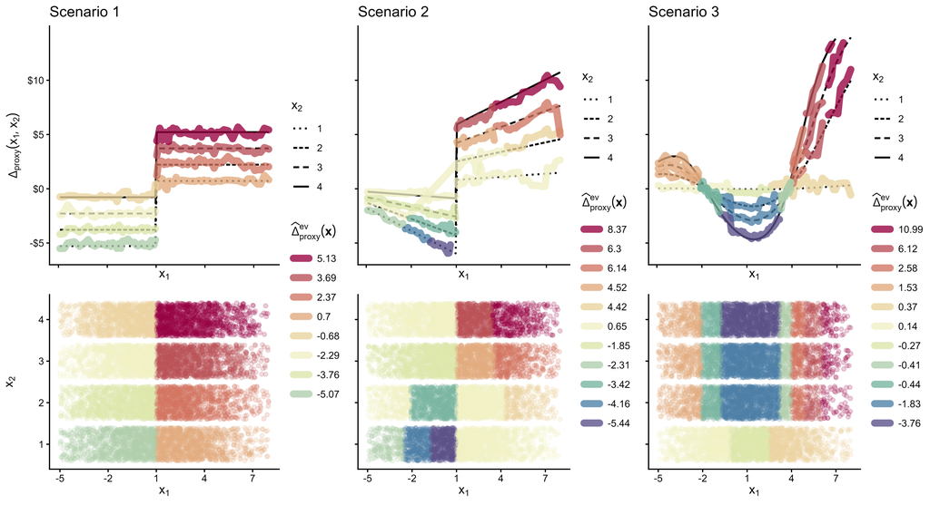

## 5.3 Experiment on partitioning proxy vulnerability for scenario 1

To support the partitioning methodology proposed in section 6 of the **main paper**, we present a simulation study to identify best practices and gain insights into optimal implementation.

Following the set of equations of Scenario 1 in Chapter 1, we simulate $M = 100$ set of $N = 3000$ samples split into $(N_{\text{train}}, N_{\text{valid}}, N_{\text{test}}) = (2000, 500, 500)$ for train, validation, and test. Our aim is to assess the capacity of the methodology to recover proxy-vulnerable distinct subpopulations, precisely identify the most at-risk groups, and accurately predict the proxy vulnerability. We compute the BIC (under Gaussian assumption) of the estimated proxy vulnerability as compared with the test theoretical proxy vulnerability, and the accuracy in the partitioning as compared with the true proxy vulnerable groups: the eight subpopulations formed by the crossing of $\{X_1 \leq 1, X_1 > 1\}$ and $X_2 \in \{1, 2, 3, 4\}$.

On each sample set, we estimated unaware and aware premiums using the methodology described in Chapter 2 and we computed proxy vulnerability $\widehat{\Delta}_{\text{proxy}}(x_1, x_2)$ via Eq. 1 of the **main paper**. We partitioned the feature space using $(X_1, X_2, D)$. Models used `rpart` (locally optimal) and `evtree` (globally optimal) regression trees, with hyperparameters tuned via validation BIC (Gaussian assumption): minimum leaf size proportion $w \in \{0.03, 0.05\}$, tree depth $d \in \{3, 4\}$, and complexity parameter $\alpha \in \{1, 2\}$. For `rpart`, we pruned a deep tree to minimize validation error. We compared performance under fixed ($k = 8$) and optimized leaf counts, retaining the best model per case for each implementation (four total).

**Code for the partition experiment.**

```r
if (!file.exists("preds/proxy_sims_results.csv")) {
  source("___evtree_experiment.R")

  # Load data
  preds_sims_stats <- jsonlite::fromJSON("preds/preds_sims_stats.json")

  # Process data
  proxy_sims_results <- process_data_evtree_experiment(preds_sims_stats)

  # Save results to CSV
  write.csv(proxy_sims_results, "preds/proxy_sims_results.csv", row.names = FALSE)
  cat("Results saved to preds/proxy_sims_results.csv")

  } else {
  proxy_sims_results <- read_csv("preds/proxy_sims_results.csv")
  cat("Results read from preds/proxy_sims_results.csv")
}
```

```
Results read from preds/proxy_sims_results.csv
```

The following table presents the results of our experiment. When the number of groups is correctly set to $k = 8$, the $8\times8$ accuracy and relaxed $8\times8$ accuracy (which counts adjacent diagonals in the confusion matrix as correct) confirm that the method effectively groups individuals, with little difference between `rpart` and `evtree`. However, when $k$ is unknown, $k = 8$ was never seen as optimal. Validation metrics (based on estimated proxy vulnerability) favor larger $k$, while oracle performance (based on theoretical proxy vulnerability) suggests better $R^2$ at $k = 8$. Whether $k$ is known or not, partitioning identifies truly vulnerable individuals (top 12% by theoretical proxy vulnerability) with over 93% precision, fulfilling its primary objective. Since $k$ is unknown in practice, strong regularization is essential to prevent excessive partitioning.

**Code for producing the experimental result table**

```r
summary_results <- proxy_sims_results %>%
  summarise(
  # Metrics for "known k" (k = 8) evtree
  k_8 = mean(proxy_sims_results$num_leaf_8, na.rm = TRUE),
  k_8_sd = sd(proxy_sims_results$num_leaf_8, na.rm = TRUE),
  minbucket_8 = mean(proxy_sims_results$minbucket_8, na.rm = TRUE),
  minbucket_8_sd = sd(proxy_sims_results$minbucket_8, na.rm = TRUE),
  maxdepth_8 = mean(proxy_sims_results$maxdepth_8, na.rm = TRUE),
  maxdepth_8_sd = sd(proxy_sims_results$maxdepth_8, na.rm = TRUE),
  alpha_8 = mean(proxy_sims_results$alpha_8, na.rm = TRUE),
  alpha_8_sd = sd(proxy_sims_results$alpha_8, na.rm = TRUE),
  validation_mse_8 = mean(proxy_sims_results$validation_mse_8, na.rm = TRUE),
  validation_mse_8_sd = sd(proxy_sims_results$validation_mse_8, na.rm = TRUE),
  oracle_r2_8 = mean(proxy_sims_results$r2_oracle_8, na.rm = TRUE),
  oracle_r2_8_sd = sd(proxy_sims_results$r2_oracle_8, na.rm = TRUE),
  acc_test_8 = mean(proxy_sims_results$accuracy_test_8, na.rm = TRUE),
  acc_test_8_sd = sd(proxy_sims_results$accuracy_test_8, na.rm = TRUE),
  relaxed_acc_test_8 = mean(proxy_sims_results$relaxed_accuracy_test_8,
                            na.rm = TRUE),
  relaxed_acc_test_8_sd = sd(proxy_sims_results$relaxed_accuracy_test_8,
                             na.rm = TRUE),
  top_acc_8 = mean(proxy_sims_results$top_acc_8, na.rm = TRUE),
  top_acc_8_sd = sd(proxy_sims_results$top_acc_8, na.rm = TRUE),
  bottom_acc_8 = mean(proxy_sims_results$bottom_acc_8, na.rm = TRUE),
  bottom_acc_8_sd = sd(proxy_sims_results$bottom_acc_8, na.rm = TRUE),
  time_8 = mean(proxy_sims_results$time_8, na.rm = TRUE),  # Time assumed same for any/known
  time_8_sd = sd(proxy_sims_results$time_8, na.rm = TRUE),



  # Metrics for "known k" (k = 8) rpart
  k_r8 = mean(proxy_sims_results$num_leaf_r8, na.rm = TRUE),
  k_r8_sd = sd(proxy_sims_results$num_leaf_r8, na.rm = TRUE),
  minbucket_r8 = mean(proxy_sims_results$minbucket_r8, na.rm = TRUE),
  minbucket_r8_sd = sd(proxy_sims_results$minbucket_r8, na.rm = TRUE),
  maxdepth_r8 = mean(proxy_sims_results$maxdepth_r8, na.rm = TRUE),
  maxdepth_r8_sd = sd(proxy_sims_results$maxdepth_r8, na.rm = TRUE),
  cp_8 = mean(proxy_sims_results$cp_8, na.rm = TRUE),
  cp_8_sd = sd(proxy_sims_results$cp_8, na.rm = TRUE),
  validation_mse_r8 = mean(proxy_sims_results$validation_mse_r8, na.rm = TRUE),
  validation_mse_r8_sd = sd(proxy_sims_results$validation_mse_r8, na.rm = TRUE),
  oracle_r2_r8 = mean(proxy_sims_results$r2_oracle_r8, na.rm = TRUE),
  oracle_r2_r8_sd = sd(proxy_sims_results$r2_oracle_r8, na.rm = TRUE),
  acc_test_r8 = mean(proxy_sims_results$accuracy_test_r8, na.rm = TRUE),
  acc_test_r8_sd = sd(proxy_sims_results$accuracy_test_r8, na.rm = TRUE),
  relaxed_acc_test_r8 = mean(proxy_sims_results$relaxed_accuracy_test_r8, na.rm = TRUE),
  relaxed_acc_test_r8_sd = sd(proxy_sims_results$relaxed_accuracy_test_r8, na.rm = TRUE),
  top_acc_r8 = mean(proxy_sims_results$top_acc_r8, na.rm = TRUE),
  top_acc_r8_sd = sd(proxy_sims_results$top_acc_r8, na.rm = TRUE),
  bottom_acc_r8 = mean(proxy_sims_results$bottom_acc_r8, na.rm = TRUE),
  bottom_acc_r8_sd = sd(proxy_sims_results$bottom_acc_r8, na.rm = TRUE),
  time_r8 = mean(proxy_sims_results$time_r8, na.rm = TRUE),  # Time assumed same for any/known
  time_r8_sd = sd(proxy_sims_results$time_r8, na.rm = TRUE),

  # Metrics for "any k" rpart
  k_rany = mean(proxy_sims_results$num_leaf_rany, na.rm = TRUE),
  k_rany_sd = sd(proxy_sims_results$num_leaf_rany, na.rm = TRUE),
  minbucket_rany = mean(proxy_sims_results$minbucket_rany, na.rm = TRUE),
  minbucket_rany_sd = sd(proxy_sims_results$minbucket_rany, na.rm = TRUE),
  maxdepth_rany = mean(proxy_sims_results$maxdepth_rany, na.rm = TRUE),
  maxdepth_rany_sd = sd(proxy_sims_results$maxdepth_rany, na.rm = TRUE),
  cp_any = mean(proxy_sims_results$cp_any, na.rm = TRUE),
  cp_any_sd = sd(proxy_sims_results$cp_any, na.rm = TRUE),
  validation_mse_rany = mean(proxy_sims_results$validation_mse_rany, na.rm = TRUE),
  validation_mse_rany_sd = sd(proxy_sims_results$validation_mse_rany, na.rm = TRUE),
  oracle_r2_rany = mean(proxy_sims_results$r2_oracle_rany, na.rm = TRUE),
  oracle_r2_rany_sd = sd(proxy_sims_results$r2_oracle_rany, na.rm = TRUE),
  top_acc_rany = mean(proxy_sims_results$top_acc_rany, na.rm = TRUE),
  top_acc_rany_sd = sd(proxy_sims_results$top_acc_rany, na.rm = TRUE),
  bottom_acc_rany = mean(proxy_sims_results$bottom_acc_rany, na.rm = TRUE),
  bottom_acc_rany_sd = sd(proxy_sims_results$bottom_acc_rany, na.rm = TRUE),
  time_rany = mean(proxy_sims_results$time_rany, na.rm = TRUE),  # Time is shared, no distinction
  time_rany_sd = sd(proxy_sims_results$time_rany, na.rm = TRUE),

    # Metrics for "any k" evtree
  k_any = mean(proxy_sims_results$num_leaf_any, na.rm = TRUE),
  k_any_sd = sd(proxy_sims_results$num_leaf_any, na.rm = TRUE),
  minbucket_any = mean(proxy_sims_results$minbucket_any, na.rm = TRUE),
  minbucket_any_sd = sd(proxy_sims_results$minbucket_any, na.rm = TRUE),
  maxdepth_any = mean(proxy_sims_results$maxdepth_any, na.rm = TRUE),
  maxdepth_any_sd = sd(proxy_sims_results$maxdepth_any, na.rm = TRUE),
  alpha_any = mean(proxy_sims_results$alpha_any, na.rm = TRUE),
  alpha_any_sd = sd(proxy_sims_results$alpha_any, na.rm = TRUE),
  validation_mse_any = mean(proxy_sims_results$validation_mse_any, na.rm = TRUE),
  validation_mse_any_sd = sd(proxy_sims_results$validation_mse_any, na.rm = TRUE),
  oracle_r2_any = mean(proxy_sims_results$r2_oracle_any, na.rm = TRUE),
  oracle_r2_any_sd = sd(proxy_sims_results$r2_oracle_any, na.rm = TRUE),
  top_acc_any = mean(proxy_sims_results$top_acc_any, na.rm = TRUE),
  top_acc_any_sd = sd(proxy_sims_results$top_acc_any, na.rm = TRUE),
  bottom_acc_any = mean(proxy_sims_results$bottom_acc_any, na.rm = TRUE),
  bottom_acc_any_sd = sd(proxy_sims_results$bottom_acc_any, na.rm = TRUE),
  time_any = mean(proxy_sims_results$time_any, na.rm = TRUE),  # Time is shared, no distinction
  time_any_sd = sd(proxy_sims_results$time_any, na.rm = TRUE),

  # Add new metrics for eo, e8, ro, r8
    recall_top_pct_eo = mean(proxy_sims_results$recall_top_pct_eo, na.rm = TRUE),
    recall_top_pct_eo_sd = sd(proxy_sims_results$recall_top_pct_eo, na.rm = TRUE),
    prec_top_pct_eo = mean(proxy_sims_results$prec_top_pct_eo, na.rm = TRUE),
    prec_top_pct_eo_sd = sd(proxy_sims_results$prec_top_pct_eo, na.rm = TRUE),
    acc_top_pct_eo = mean(proxy_sims_results$acc_top_pct_eo, na.rm = TRUE),
    acc_top_pct_eo_sd = sd(proxy_sims_results$acc_top_pct_eo, na.rm = TRUE),
    effpct_top_pct_eo = mean(proxy_sims_results$effpct_top_pct_eo, na.rm = TRUE),
    effpct_top_pct_eo_sd = sd(proxy_sims_results$effpct_top_pct_eo, na.rm = TRUE),
```

```r
    recall_top_pct_e8 = mean(proxy_sims_results$recall_top_pct_e8, na.rm = TRUE),
    recall_top_pct_e8_sd = sd(proxy_sims_results$recall_top_pct_e8, na.rm = TRUE),
    prec_top_pct_e8 = mean(proxy_sims_results$prec_top_pct_e8, na.rm = TRUE),
    prec_top_pct_e8_sd = sd(proxy_sims_results$prec_top_pct_e8, na.rm = TRUE),
    acc_top_pct_e8 = mean(proxy_sims_results$acc_top_pct_e8, na.rm = TRUE),
    acc_top_pct_e8_sd = sd(proxy_sims_results$acc_top_pct_e8, na.rm = TRUE),
    effpct_top_pct_e8 = mean(proxy_sims_results$effpct_top_pct_e8, na.rm = TRUE),
    effpct_top_pct_e8_sd = sd(proxy_sims_results$effpct_top_pct_e8, na.rm = TRUE),

    recall_top_pct_ro = mean(proxy_sims_results$recall_top_pct_ro, na.rm = TRUE),
    recall_top_pct_ro_sd = sd(proxy_sims_results$recall_top_pct_ro, na.rm = TRUE),
    prec_top_pct_ro = mean(proxy_sims_results$prec_top_pct_ro, na.rm = TRUE),
    prec_top_pct_ro_sd = sd(proxy_sims_results$prec_top_pct_ro, na.rm = TRUE),
    acc_top_pct_ro = mean(proxy_sims_results$acc_top_pct_ro, na.rm = TRUE),
    acc_top_pct_ro_sd = sd(proxy_sims_results$acc_top_pct_ro, na.rm = TRUE),
    effpct_top_pct_ro = mean(proxy_sims_results$effpct_top_pct_ro, na.rm = TRUE),
    effpct_top_pct_ro_sd = sd(proxy_sims_results$effpct_top_pct_ro, na.rm = TRUE),

    recall_top_pct_r8 = mean(proxy_sims_results$recall_top_pct_r8, na.rm = TRUE),
    recall_top_pct_r8_sd = sd(proxy_sims_results$recall_top_pct_r8, na.rm = TRUE),
    prec_top_pct_r8 = mean(proxy_sims_results$prec_top_pct_r8, na.rm = TRUE),
    prec_top_pct_r8_sd = sd(proxy_sims_results$prec_top_pct_r8, na.rm = TRUE),
    acc_top_pct_r8 = mean(proxy_sims_results$acc_top_pct_r8, na.rm = TRUE),
    acc_top_pct_r8_sd = sd(proxy_sims_results$acc_top_pct_r8, na.rm = TRUE),
    effpct_top_pct_r8 = mean(proxy_sims_results$effpct_top_pct_r8, na.rm = TRUE),
    effpct_top_pct_r8_sd = sd(proxy_sims_results$effpct_top_pct_r8, na.rm = TRUE)
)

# Step 3: Transform results into a cleaner format
summary_table <- data.frame(
  Metric = c(
    "Number of Leaves (k)", "Min Split", "Max Depth", "Alpha",
    "Validation BIC", "Oracle R²", "Accuracy Test", "Relaxed Accuracy Test",
    "Top Accuracy", "Bottom Accuracy", "Detect recall", "Detect effective %", "Time"
  ),
  Rpart_Known_k_Mean = c(
    summary_results$k_r8, summary_results$minbucket_r8, summary_results$maxdepth_r8,
    summary_results$cp_8, summary_results$validation_mse_r8, summary_results$oracle_r2_r8,
    summary_results$acc_test_r8, summary_results$relaxed_acc_test_r8,
    summary_results$top_acc_r8, summary_results$bottom_acc_r8, summary_results$recall_top_pct_r8, summary_results$effpct_top_pct_r8, summary_results$time_r8
  ),
  Rpart_Known_k_SD = c(
    summary_results$k_r8_sd, summary_results$minbucket_r8_sd, summary_results$maxdepth_r8_sd,
    summary_results$cp_8_sd, summary_results$validation_mse_r8_sd, summary_results$oracle_r2_r8_sd,
    summary_results$acc_test_r8_sd, summary_results$relaxed_acc_test_r8_sd,
    summary_results$top_acc_r8_sd, summary_results$bottom_acc_r8_sd,  summary_results$recall_top_pct_r8_sd, summary_results$effpct_top_pct_r8_sd, summary_results$time_r8_sd
  ),
  Ev_Known_k_Mean = c(
    summary_results$k_8, summary_results$minbucket_8, summary_results$maxdepth_8,
    summary_results$alpha_8, summary_results$validation_mse_8, summary_results$oracle_r2_8,
    summary_results$acc_test_8, summary_results$relaxed_acc_test_8,
    summary_results$top_acc_8, summary_results$bottom_acc_8,summary_results$recall_top_pct_e8, summary_results$effpct_top_pct_e8,  summary_results$time_8
  ),
  Ev_Known_k_SD = c(
    summary_results$k_8_sd, summary_results$minbucket_8_sd, summary_results$maxdepth_8_sd,
    summary_results$alpha_8_sd, summary_results$validation_mse_8_sd, summary_results$oracle_r2_8_sd,
    summary_results$acc_test_8_sd, summary_results$relaxed_acc_test_8_sd,
    summary_results$top_acc_8_sd, summary_results$bottom_acc_8_sd,summary_results$recall_top_pct_e8_sd, summary_results$effpct_top_pct_e8_sd,  summary_results$time_8_sd
  ),
   Rpart_Any_k_Mean = c(
    summary_results$k_rany, summary_results$minbucket_rany, summary_results$maxdepth_rany,
    summary_results$cp_any, summary_results$validation_mse_rany, summary_results$oracle_r2_rany,
    NA, NA,  # Accuracy metrics not available for Any k
    summary_results$top_acc_rany, summary_results$bottom_acc_rany, summary_results$recall_top_pct_ro, summary_results$effpct_top_pct_ro, summary_results$time_rany
  ),
  Rpart_Any_k_SD = c(
    summary_results$k_rany_sd, summary_results$minbucket_rany_sd, summary_results$maxdepth_rany_sd,
    summary_results$cp_any_sd, summary_results$validation_mse_rany_sd, summary_results$oracle_r2_rany_sd,
    NA, NA,  # Accuracy metrics not available for Any k
    summary_results$top_acc_rany_sd, summary_results$bottom_acc_rany_sd, summary_results$recall_top_pct_ro_sd, summary_results$effpct_top_pct_ro_sd, summary_results$time_rany_sd
  ),
  Ev_Any_k_Mean = c(
    summary_results$k_any, summary_results$minbucket_any, summary_results$maxdepth_any,
    summary_results$alpha_any, summary_results$validation_mse_any, summary_results$oracle_r2_any,
    NA, NA,  # Accuracy metrics not available for Any k
    summary_results$top_acc_any, summary_results$bottom_acc_any,summary_results$recall_top_pct_eo, summary_results$effpct_top_pct_eo,  summary_results$time_any
  ),
  Ev_Any_k_SD = c(
    summary_results$k_any_sd, summary_results$minbucket_any_sd, summary_results$maxdepth_any_sd,
    summary_results$alpha_any_sd, summary_results$validation_mse_any_sd, summary_results$oracle_r2_any_sd,
    NA, NA,  # Accuracy metrics not available for Any k
    summary_results$top_acc_any_sd, summary_results$bottom_acc_any_sd, summary_results$recall_top_pct_eo_sd, summary_results$effpct_top_pct_eo_sd,  summary_results$time_any_sd
  ),
  group = c('Hyperparam.', 'Hyperparam.', 'Hyperparam.', 'Hyperparam.',
            'Efficiency', 'Oracle perf.', 'Oracle perf.', 'Oracle perf.', 'Oracle perf.', 'Oracle perf.',
            'Efficiency', 'Efficiency', 'Efficiency') |> factor(levels = c('Hyperparam.', 'Efficiency', 'Oracle perf.'))
)
```

```r
library(knitr)
library(kableExtra)

## round
summary_table[, 2:9] <- round(summary_table[,2:9], 3)
table_to_g <- summary_table[,c('Metric',
                               "Rpart_Known_k_Mean", "Rpart_Known_k_SD",
                               "Ev_Known_k_Mean", "Ev_Known_k_SD",
                               "Rpart_Any_k_Mean", "Rpart_Any_k_SD",
                               "Ev_Any_k_Mean", "Ev_Any_k_SD", "group")] |>
  arrange(group)

# Add group column to the beginning
table_to_g <- table_to_g |> relocate(group)

# Row breaks after last row of each group
group_lines <- c(5, 9)

# Create table with custom header
kbl(table_to_g |> dplyr::select(-group), col.names = NULL,
    caption = "Results of experimental testing. For each of the $N = 100$ samples, we obtained the best regression trees when forcing $k = 8$ or when $k$ was part of the tuned hyperparameters.",
    label = "experiment") %>%
  add_header_above(c(
    "Metric" = 1,
    "Mean" = 1, "SD" = 1,
    "Mean" = 1, "SD" = 1,
    "Mean" = 1, "SD" = 1,
    "Mean" = 1, "SD" = 1
  )) %>%
  add_header_above(c(
    " " = 1,
    "Greedy tree \n (rpart)" = 2,
    "Optimal tree \n (evtree)" = 2,
    "Greedy tree \n (rpart)" = 2,
    "Optimal tree \n (evtree)" = 2
  )) %>% add_header_above(c(
    " " = 1,
    "Known k" = 4,
    "Unknown k" = 4
  ), escape = FALSE) %>%
  group_rows(index = table(table_to_g$group)) %>%
  row_spec(group_lines, extra_css = "border-top: 2px solid black;") %>%
  kable_styling(full_width = FALSE, bootstrap_options = c("striped", "hover"))
```

Results of experimental testing. For each of the $N = 100$ samples, we obtained the best regression trees when forcing $k = 8$ or when $k$ was part of the tuned hyperparameters.

| Metric | Known k Greedy tree (rpart) Mean | Known k Greedy tree (rpart) SD | Known k Optimal tree (evtree) Mean | Known k Optimal tree (evtree) SD | Unknown k Greedy tree (rpart) Mean | Unknown k Greedy tree (rpart) SD | Unknown k Optimal tree (evtree) Mean | Unknown k Optimal tree (evtree) SD |
| --- | --- | --- | --- | --- | --- | --- | --- | --- |
| **Hyperparam.** |  |  |  |  |  |  |  |  |
| Number of Leaves (k) | 8.000 | 0.000 | 8.000 | 0.000 | 14.290 | 1.192 | 12.290 | 1.908 |
| Min Split | 0.037 | 0.010 | 0.037 | 0.010 | 0.032 | 0.005 | 0.031 | 0.005 |
| Max Depth | 3.150 | 0.359 | 3.150 | 0.359 | 3.990 | 0.100 | 3.970 | 0.171 |
| Alpha | 0.005 | 0.003 | 1.470 | 0.502 | 0.000 | 0.000 | 1.390 | 0.490 |
| **Efficiency** |  |  |  |  |  |  |  |  |
| Validation BIC | 90.892 | 155.067 | Inf | NaN | 39.851 | 165.704 | 7.816 | 158.082 |
| Detect recall | 0.951 | 0.118 | 0.959 | 0.104 | 0.907 | 0.153 | 0.926 | 0.136 |
| Detect effective % | 0.171 | 0.068 | 0.183 | 0.072 | 0.152 | 0.042 | 0.161 | 0.052 |
| Time | 0.016 | 0.007 | 23.083 | 7.086 | 0.015 | 0.007 | 43.037 | 14.681 |
| **Oracle perf.** |  |  |  |  |  |  |  |  |
| Oracle R² | 0.905 | 0.036 | 0.904 | 0.038 | 0.897 | 0.034 | 0.894 | 0.035 |
| Accuracy Test | 0.601 | 0.165 | 0.649 | 0.167 | NA | NA | NA | NA |
| Relaxed Accuracy Test | 0.971 | 0.051 | 0.976 | 0.047 | NA | NA | NA | NA |
| Top Accuracy | 0.941 | 0.076 | 0.932 | 0.079 | 0.957 | 0.064 | 0.951 | 0.067 |
| Bottom Accuracy | 0.942 | 0.077 | 0.939 | 0.076 | 0.967 | 0.056 | 0.964 | 0.051 |

Grubinger, Thomas, Achim Zeileis, and Karl-Peter Pfeiffer. 2014. “Evtree: Evolutionary Learning of Globally Optimal Classification and Regression Trees in r.” *Journal of Statistical Software* 61 (1): 1–29. https://doi.org/10.18637/jss.v061.i01.

Lin, Jimmy, Chudi Zhong, Diane Hu, Cynthia Rudin, and Margo Seltzer. 2020. “Generalized and Scalable Optimal Sparse Decision Trees.” *Proceedings of the 37th International Conference on Machine Learning* 119: 6150–60. https://proceedings.mlr.press/v119/lin20g.html.

History

Loading…